# Ejemplo 3

Luca Riccardi

10/2021

# Ejemplo 3

## Enunciado

Un agricoltor tiene que elegir cuál semilla plantear entre tomate (d1), patata (d2), zanahoria (d3) y lechuga (d4). Los precios de ventea son respectivamente:

- $5€/Kg$
- $8€/kg$
- $2€/Kg$
- $4€/Kg$

Los costes de preparación de la tierra y de las semilla son:

- $190€$ para el tomate
- $250€$ para la lechuga
- $300€$ para las verduras que crecen bajo tierra (patata y zanahorias)

Sabiendo que el campo se siembra de manera diferente según la hortaliza (es necesario emplear $200 m^2$ por el tomate, $300 m^2$ por las patatas y $250 m^2$ por la zanahoria y $400 m^2$ por la lechuga) y que, a diferencia de las condiciones climáticas, se pueden cosechar distintas cantidades de hortalizas:

1. Clima cálido y húmedo con lluvias frecuentes (e1), con el que se puede recogir $150Kg$ de tomates, $100Kg$ de patatas, $500Kg$ de zanahorias y $50Kg$ de lechuga (Sin gastos de riego).
2. Clima cálido y seco con poca lluvia (e2), con el que se puede recogir $400Kg$ de tomates, $200Kg$ de patatas, $500Kg$ de Zanahorias y $280Kg$ de lechuga. Gastos de riego: $6€/m^2$ por el tomate, $3€/m^2$ por la patata, $2€/m^2$ por la zanahoria y $1€/m^2$ por la lechuga . En este caso, el agricultor no puede aumentar el precio de ventea.
3. Clima cálido y seco sin lluvia (e3), con la que se puede recogir $300Kg$ de tomate, $200Kg$ de patatas, $400Kg$ de Zanahorias y $300Kg$ de lechuga. Gastos de riego: $8€/m^2$ por el tomate, $4€/m^2$ por la patata, $3€/m^2$ por la zanahoria y $1.5€/m^2$ por la lechuga. En este caso, el agricultor aumentará el precio de CADA verdura en $1,5 €/Kg$ (para hacer frente a los costes de riego de las plantas).

¿Qué semilla plantará el agricultor para maximizar las ganancias?

```r
tb01 =  crea.tablaX(vector_matporfilas = c(
  5*150 - 190,5*400 - (190+6*200),6.5*300 - (190+8*200),
  8*100 - 300,8*200 - (300+3*300),9.5*200 - (300+4*300),
  2*500 - 300,2*500 - (300+2*250),3.5*400 - (300+3*250),
  4*50 - 250,4*280 - (250+1*400),5.5*300 - (250+1.5*400)), numalternativas = 4, numestados = 3)
tb01
```

```
##     e1  e2  e3
## d1 560 610 160
## d2 500 400 400
## d3 700 200 350
## d4 -50 470 800
```

```r
Sol = criterio.Todos(tb01, alfa = 0.5, favorable = T)
Sol
```

```
##                   e1   e2   e3 Wald Optimista Hurwicz Savage Laplace
## d1               560  610  160  160       610     385    640   443.3
## d2               500  400  400  400       500     450    400   433.3
## d3               700  200  350  200       700     450    450   416.7
## d4               -50  470  800  -50       800     375    750   406.7
## iAlt.Opt (fav.) <NA> <NA> <NA>   d2        d4   d2,d3     d2      d1
##                 Punto Ideal
## d1                    655.1
## d2                    494.1
## d3                    608.8
## d4                    763.0
## iAlt.Opt (fav.)          d2
```

- *Criterio de Wald*: la alternativa óptima sería `d2` (patata)
- *Criterio optimista*: la alternativa óptima es `d4` (lechuga)
- *Criterio de Hurwicz con alfa=0.5* : la alternativa óptima es `d2` y `d3` (patata y zanahoria)
- *Criterio de Savage*: la alternativa óptima es `d2` (patata)
- *Criterio de Laplace*: las alternativas óptimas son `d1` (tomate)
- *Criterio del Punto Ideal*: la alternativa óptima es `d2` (patata)

Vamos a aplicar el Criterio de Hurwicz para distintos valores de alfa:

```r
solH = criterio.Hurwicz.General(tb01, alfa = 0.4, favorable = T)
solH
```

```
## $criterio
## [1] "Hurwicz"
##
## $alfa
## [1] 0.4
##
## $metodo
## [1] "favorable"
##
## $tablaX
##     e1  e2  e3
## d1 560 610 160
## d2 500 400 400
## d3 700 200 350
## d4 -50 470 800
##
## $ValorAlternativas
##  d1  d2  d3  d4
## 340 440 400 290
##
## $ValorOptimo
## [1] 440
##
## $AlternativaOptima
## d2
##  2
```

Para alfa = 0.4, la alternativa óptima sería `d2` (patata)

```r
solH1 = criterio.Hurwicz.General(tb01, alfa = 0.6, favorable = T)
solH1
```

```
## $criterio
## [1] "Hurwicz"
##
## $alfa
## [1] 0.6
##
## $metodo
## [1] "favorable"
##
## $tablaX
##     e1  e2  e3
## d1 560 610 160
## d2 500 400 400
## d3 700 200 350
## d4 -50 470 800
##
## $ValorAlternativas
##  d1  d2  d3  d4
## 430 460 500 460
##
## $ValorOptimo
## [1] 500
##
## $AlternativaOptima
## d3
##  3
```

Para alfa = 0.6, la alternativa óptima sería d3 (zanahoria)

```r
solH2 = criterio.Hurwicz.General(tb01, alfa = 0.8, favorable = T)
solH2
```

```
## $criterio
## [1] "Hurwicz"
##
## $alfa
## [1] 0.8
##
## $metodo
## [1] "favorable"
##
## $tablaX
##     e1  e2  e3
## d1 560 610 160
## d2 500 400 400
## d3 700 200 350
## d4 -50 470 800
##
## $ValorAlternativas
##  d1  d2  d3  d4
## 520 480 600 630
##
## $ValorOptimo
## [1] 630
##
## $AlternativaOptima
## d4
##  4
```

### FUNCION

```r
Intervalo = Hurwicz.intervalos(tb01, favorable = T)
```

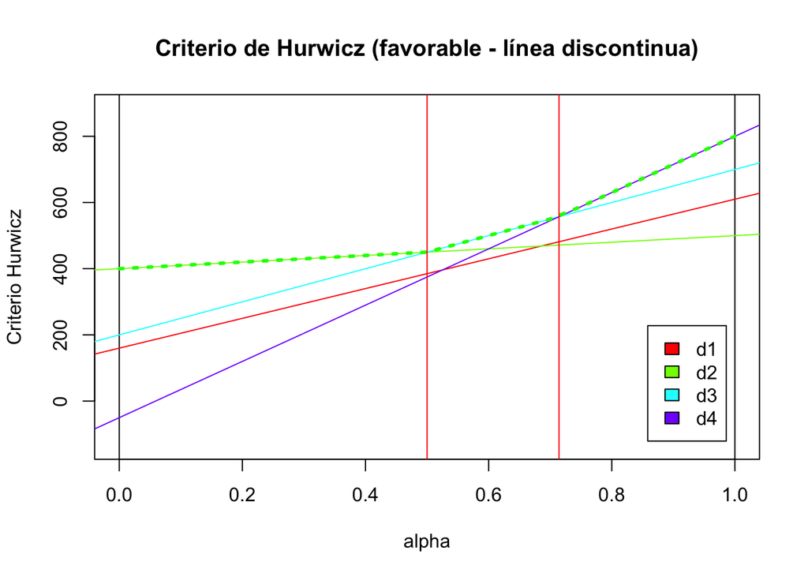

```r
Intervalo
```

```
## $AltOptimas
## [1] 2 3 4
##
## $PuntosDeCorte
## [1] 0.500 0.714
##
## $IntervalosAlfa
##            Intervalo         Alternativa
## Soluciones "( 0 , 0.5 )"     "2"
##            "( 0.5 , 0.714 )" "3"
##            "( 0.714 , 1 )"   "4"
```